# Machine Learning Approaches to the Million Song Dataset

### Marc Anthony B Reyes

Growth Data Analyst Applicant | hello@marcreyes.ph | (+63)9129152323

- Part 1: Identifying Popular Music and Predicting Music "Hotness" with XGBoost-trained model and Spotify API
- Part 2: Popularity-based Song Recommender

## Part 1: Identifying Popular Music and Predicting Music "Hotness" with XGBoost-trained model and Spotify API

On this part, we trained Machine Learning models to predict music hotness of a Spotify music track using songs from the million songs dataset that appeared on the Billboard Hot 100 chart.

```python
# Library imports
from bs4 import BeautifulSoup
from datetime import date, datetime, timedelta
from dateutil import parser
from lib import Request_API
from matplotlib import rcParams
from sklearn import metrics, preprocessing, svm
from sklearn.ensemble import RandomForestClassifier
from sklearn.metrics import accuracy_score, roc_auc_score
from sklearn.model_selection import cross_val_score, KFold, train_test_split
from xgboost.sklearn import XGBClassifier, XGBRegressor
import copy
import matplotlib
import matplotlib.pyplot as plt
import numpy as np
import pandas as pd
import pickle
import re
import requests
import seaborn as sns
import string
import warnings
import xgboost as xgb

plt.style.use('fivethirtyeight')
rcParams['font.size'] = 15
warnings.filterwarnings("ignore")
```

```python
# Read file and store into a dataframe. Notice that we used a
# different data. This data excluded some columns to make
# sure the reading and analysis process will run faster even
# on computers will low memory.
song_data_features = pd.read_csv('data/song_data_features.csv')

# Show the first (5) rows of the dataframe
song_data_features.head()
```

|  | artist_familiarity | artist_hotttnesss | artist_id | artist_latitude | artist_location | artist_longitude | artist_name | duration | end_of_fade_in | key | ... | mode | mode_confidence | release | song_hotttnesss | start_of_fade_out | tempo | time_signature | time_signature_confidence | title | year |
| --- | --- | --- | --- | --- | --- | --- | --- | --- | --- | --- | --- | --- | --- | --- | --- | --- | --- | --- | --- | --- | --- |
| 0 | 0.649822 | 0.394032 | ARYZTJS1187B98C555 | NaN | NaN | NaN | Faster Pussy cat | 252.05506 | 2.049 | 10 | ... | 0 | 0.688 | Monster Ballads X-Mas | 0.542899 | 236.635 | 87.002 | 4 | 0.940 | Silent Night | 2003 |
| 1 | 0.439604 | 0.356992 | ARMVN3U1187FB3A1EB | NaN | NaN | NaN | Karkkiautomaatti | 156.55138 | 0.258 | 9 | ... | 1 | 0.355 | Karkuteillä | 0.299877 | 148.660 | 150.778 | 1 | 0.000 | Tanssi vaan | 1995 |
| 2 | 0.643681 | 0.437504 | ARGEKB01187FB50750 | 55.8578 | Glasgow, Scotland | -4.24251 | Hudson Mohawke | 138.97098 | 0.000 | 7 | ... | 1 | 0.566 | Butter | 0.617871 | 138.971 | 177.768 | 4 | 0.446 | No One Could Ever | 2006 |
| 3 | 0.448501 | 0.372349 | ARNWYLR1187B9B2F9C | NaN | NaN | NaN | Yerba Brava | 145.05751 | 0.000 | 7 | ... | 1 | 0.451 | De Culo | NaN | 138.687 | 87.433 | 4 | 0.000 | Si Vos Querés | 2003 |
| 4 | 0.000000 | 0.000000 | AREQDTE1269FB37231 | NaN | NaN | NaN | Der Mystic | 514.29832 | 0.000 | 5 | ... | 0 | 0.290 | Rene Ablaze Presents Winter Sessions | NaN | 506.717 | 140.035 | 4 | 0.315 | Tangle Of Aspens | 0 |

5 rows × 22 columns

```python
# Exclude rows with missing values
indices_to_keep = ~song_data_features.isin([np.nan, np.inf, -np.inf]).any(1)

# Assign cleaned dataframe to itself so as to save cleaned dataframe in memory
song_data_features = song_data_features[indices_to_keep]
```

```python
# Show the first five (5) rows of the dataframe
song_data_features.head()
```

|  | artist_familiarity | artist_hotttnesss | artist_id | artist_latitude | artist_location | artist_longitude | artist_name | duration | end_of_fade_in | key | ... | mode | mode_confidence | release | song_hotttnesss | start_of_fade_out | tempo | time_signature | time_signature_confidence | title | year |
| --- | --- | --- | --- | --- | --- | --- | --- | --- | --- | --- | --- | --- | --- | --- | --- | --- | --- | --- | --- | --- | --- |
| 2 | 0.643681 | 0.437504 | ARGEKB01187FB50750 | 55.85780 | Glasgow, Scotland | -4.24251 | Hudson Mohawke | 138.97098 | 0.000 | 7 | ... | 1 | 0.566 | Butter | 0.617871 | 138.971 | 177.768 | 4 | 0.446 | No One Could Ever | 2006 |
| 15 | 0.529819 | 0.410229 | ARSB5591187B99A848 | 57.42635 | Vetlanda, Sweden | 15.08518 | Lena Philipsson | 262.26893 | 0.194 | 11 | ... | 1 | 0.337 | Lena 20 År | 0.212045 | 259.419 | 122.332 | 4 | 0.905 | 006 | 1998 |
| 16 | 0.685503 | 0.446733 | ARDW5AW1187FB55708 | 42.78668 | Vermillion, SD | -96.92803 | Shawn Colvin | 216.47628 | 2.032 | 6 | ... | 1 | 0.655 | Cover Girl | 0.270776 | 208.062 | 99.214 | 4 | 0.000 | (Looking For) The Heart Of Saturday | 1994 |
| 17 | 0.734471 | 0.511976 | ARGWPP11187B9AEF43 | 38.82350 | Maryland | -75.92381 | Dying Fetus | 196.02240 | 0.000 | 8 | ... | 1 | 0.146 | Descend Into Depravity | 0.614766 | 185.202 | 189.346 | 7 | 0.864 | Ethos of Coercion | 2009 |
| 33 | 0.740252 | 0.472691 | AR79L0D1187FB3AFB6 | 51.45180 | Essen | 7.01062 | Kreator | 372.42730 | 0.000 | 7 | ... | 1 | 0.396 | Violent revolution | 0.788727 | 355.062 | 191.665 | 3 | 0.665 | All of the same blood | 2001 |

5 rows × 22 columns

### Comparing Classification Models

On this part, we trained the various classification models with the Million Song Datataset data and compare its accuracy. We then use the model with the highest accuracy to predict the "hotness" of a music using Spotify API. We compared the following models and identified the one with the highest accuracy.

- Random forest classifier
- XGBoost classifier (XGB)
- Logistic regression
- k-Nearest neighbor (kNN)
- Support vector machine (SVC)
- Decision tree
- Stochastic gradient descent (SGD)

We are dependent on the songs that have appeared on the Billboard Hot 100 chart as our training data and we will use this to make predictions of Spotify music's hotness.

```python
# Read hot billboard songs data and store into a dataframe
hot_billboard_songs = pd.read_csv("data/hot_billboard_songs.csv")

# Show the first five (5) rows of the dataframe
hot_billboard_songs.head()
```

|  | artist | publish_date | track |
| --- | --- | --- | --- |
| 0 | Ricky Nelson | 1958-08-09 | Poor Little Fool |
| 1 | Domenico Modugno | 1958-08-09 | Nel Blu Dipinto Di Blu (Volaré) |
| 2 | Perez Prado And His Orchestra | 1958-08-09 | Patricia |
| 3 | Bobby Darin | 1958-08-09 | Splish Splash |
| 4 | Kalin Twins | 1958-08-09 | When |

```python
# Get the names of the tracks in the billboard hot 100 data
bb_tracks = list(hot_billboard_songs.track)

# Function to flag rows of songs that appear in the hot 100 data (1)
# and 0 if otherwise.
def find_target(row):
    lst = bb_tracks
    if row['title'] in lst:
        return 1
    else:
        return 0
```

```python
# New column to identify if a song is hot (1) or not (0)
# A hot song should appear on Billboard hot 100 data
song_data_features['is_hot_billboard'] = song_data_features.apply(find_target, axis=1)
```

```python
# Encode_artist id into quantitative label encoder and store in a dataframe column
le = preprocessing.LabelEncoder()
song_data_features['artist_id'] = le.fit_transform(song_data_features['artist_id'].astype('str'))
```

```python
# Function to graph distribution of an attribute of songs that are hot
def freq(col):
   g = sns.kdeplot(song_data_features[col][(song_data_features["is_hot_billboard"] == 1)], color="Blue", shade = True)
   g.set_xlabel(col)
   g.set_ylabel("Frequency")
   g = g.legend(["1"])
   plt.show()
```

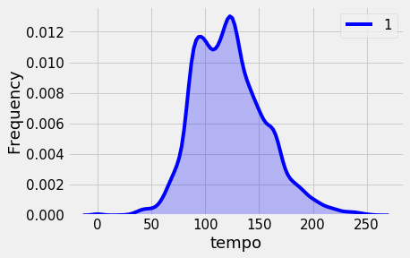

```python
# Graph frequency of tempo variable of songs that are hot (have appeared
# on the Billboard Hot 100 Chart (1)
freq("tempo")
```

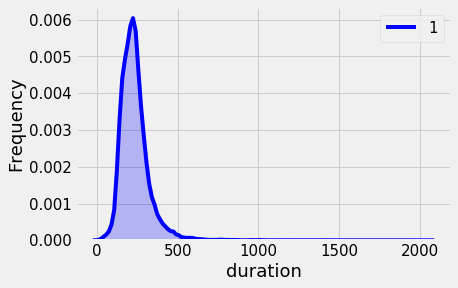

```python
# Graph frequency of duration variable of songs that are hot (have appeared
# on the Billboard Hot 100 Chart (1)
freq("duration")
```

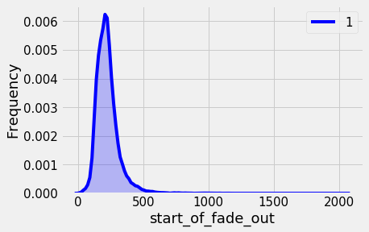

```python
# Graph frequency of start_of_fade_out variable of songs that are hot (have appeared
# on the Billboard Hot 100 Chart (1)
freq("start_of_fade_out")
```

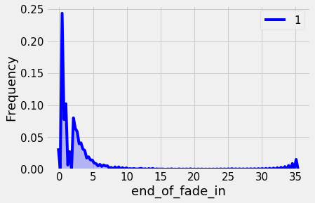

```python
# Graph frequency of end_of_fade_in variable of songs that are hot (have appeared
# on the Billboard Hot 100 Chart (1)
freq("end_of_fade_in")
```

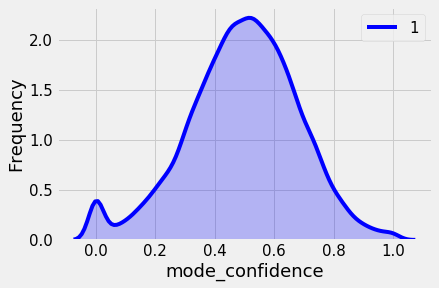

```python
# Graph frequency of mode_confidence variable of songs that are hot (have appeared
# on the Billboard Hot 100 Chart (1)
freq("mode_confidence")
```

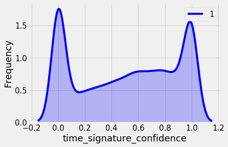

```python
# Graph frequency of time_signature_confidence variable of songs that are hot (have appeared
# on the Billboard Hot 100 Chart (1)
freq("time_signature_confidence")
```

```python
# Show information of the dataframe columns
song_data_features.info()
```

```
<class 'pandas.core.frame.DataFrame'>
Int64Index: 212793 entries, 2 to 999989
Data columns (total 23 columns):
artist_familiarity           212793 non-null float64
artist_hotttnesss            212793 non-null float64
artist_id                    212793 non-null int64
artist_latitude              212793 non-null float64
artist_location              212793 non-null object
artist_longitude             212793 non-null float64
artist_name                  212793 non-null object
duration                     212793 non-null float64
end_of_fade_in               212793 non-null float64
key                          212793 non-null int64
key_confidence               212793 non-null float64
loudness                     212793 non-null float64
mode                         212793 non-null int64
mode_confidence              212793 non-null float64
release                      212793 non-null object
song_hotttnesss              212793 non-null float64
start_of_fade_out            212793 non-null float64
tempo                        212793 non-null float64
time_signature               212793 non-null int64
time_signature_confidence    212793 non-null float64
title                        212793 non-null object
year                         212793 non-null int64
is_hot_billboard             212793 non-null int64
dtypes: float64(13), int64(6), object(4)
memory usage: 39.0+ MB
```

```python
# Drop unncessary columns and save remaining columns as our training data
drop_list = ['artist_location', 'artist_latitude', 'artist_longitude','artist_name', 'release', 'title' ,'song_hotttnesss']

# Our training data (is yet to be filtered)
train = song_data_features.drop(drop_list, axis=1)
```

```python
# Show information of the dataframe columns
train.info()
```

```
<class 'pandas.core.frame.DataFrame'>
Int64Index: 212793 entries, 2 to 999989
Data columns (total 16 columns):
artist_familiarity           212793 non-null float64
artist_hotttnesss            212793 non-null float64
artist_id                    212793 non-null int64
duration                     212793 non-null float64
end_of_fade_in               212793 non-null float64
key                          212793 non-null int64
key_confidence               212793 non-null float64
loudness                     212793 non-null float64
mode                         212793 non-null int64
mode_confidence              212793 non-null float64
start_of_fade_out            212793 non-null float64
tempo                        212793 non-null float64
time_signature               212793 non-null int64
time_signature_confidence    212793 non-null float64
year                         212793 non-null int64
is_hot_billboard             212793 non-null int64
dtypes: float64(10), int64(6)
memory usage: 27.6 MB
```

```python
# Our ground truth Y feature
Y = copy.deepcopy(train.is_hot_billboard)
Y.shape
```

```
(212793,)
```

```python
# Fill null artist_familiarity column values with its
# median and store values again to the column
train["artist_familiarity"] = train["artist_familiarity"].fillna(train["artist_familiarity"].median())
```

```python
# Drop the is_hot_billboard column
train1 = train.drop("is_hot_billboard", axis=1)
```

```python
# Prepare data for training. Here we split our training data
# and ground truth label into test and training data
X_train, X_test, y_train, y_test = train_test_split(train1, Y, test_size=0.33, random_state=7)
model = XGBClassifier()
model.fit(X_train, y_train)

# Make predictions for test data
y_pred = model.predict(X_test)
accuracy = model.score(X_test, y_test)
# Show accuracy of the prediction on our test data
print("Accuracy: %.2f%%" % (accuracy * 100.0))
```

```
Accuracy: 87.59%
```

```python
# Library imports
from sklearn.model_selection import cross_val_score

# Function to evaluate models with cross validation
def testingModel(model, X_train, Y_train):
    scores = cross_val_score(model, X_train, Y_train, cv=10, scoring = "roc_auc")
    print("Scores:", scores)
    print("Mean:", scores.mean())
    print("Standard Deviation:", scores.std())
    return scores.mean()
```

### Accuracy of Machine Learning Models over Training Data

On this part, we will be identifying the model that has the highest cross validation score and we will be using that to train our data.

**A. Random Forest Classifier**

```python
# Create a Random forest classifier model instance
rf = RandomForestClassifier(n_estimators=100, oob_score = True)
# Fit training data
rf.fit(train1, Y)
# Test accuracy over training data
acc_random_forest = testingModel(rf, train1, Y)
```

```
Scores: [0.61007321 0.6131111  0.61157565 0.60741735 0.60077081 0.60424784
 0.60477909 0.60407138 0.59890568 0.60207949]
Mean: 0.6057031597738982
Standard Deviation: 0.004479942892587618
```

**B. XGBoost Classifier**

```python
# Create XGBoost forest classifier model instance
xgb1 = XGBClassifier(learning_rate =0.1,
                     n_estimators=100,
                     max_depth=5,
                     min_child_weight=1,
                     gamma=0,
                     subsample=0.8,
                     colsample_bytree=0.8,
                     objective= 'binary:logistic',
                     nthread=4,
                     scale_pos_weight=1,
                     seed=27)
# Fit training data
xgb1.fit(train1, Y)
# Test accuracy over training data
acc_xgb = testingModel(xgb1, train1, Y)
```

```
Scores: [0.63215235 0.62010208 0.62716429 0.62417527 0.62072341 0.62459626
 0.62428749 0.62184373 0.62536882 0.61763217]
Mean: 0.6238045859769444
Standard Deviation: 0.0038673369418834955
```

**C. Logistic Regression**

```python
# Libary import
from sklearn.linear_model import LogisticRegression
# Create logistic regression model instance
logreg = LogisticRegression()
# First training data
logreg.fit(train1, Y)
# Test accuracy over training data
acc_log = testingModel(logreg, train1, Y)
```

```
Scores: [0.54232408 0.54253635 0.53831783 0.53497718 0.53314216 0.53845933
 0.5363628  0.54018867 0.52661326 0.53242868]
Mean: 0.5365350343050648
Standard Deviation: 0.004680077064508522
```

**D. k-Nearest Neighbor**

```python
# Libary import
from sklearn.neighbors import KNeighborsClassifier
# Create k-neareast neighbor model instance
knn = KNeighborsClassifier(n_neighbors = 3)
# Fit training data
knn.fit(train1, Y)
# Test accuracy over training data
acc_knn = testingModel(knn, train1, Y)
```

```
Scores: [0.54226469 0.55067176 0.55472438 0.55595821 0.54777695 0.55015996
 0.54811476 0.55029248 0.54927092 0.54563061]
Mean: 0.5494864715480807
Standard Deviation: 0.003790770383179525
```

**E. Support Vector Machines**

```python
# Libary imports
from sklearn.svm import SVC, LinearSVC
# Create support vector machine model instance
linear_svc = LinearSVC()
# Fit training data
linear_svc.fit(train1, Y)
# Test accuracy over training data
acc_linear_svc = testingModel(linear_svc, train1, Y)
```

```
Scores: [0.48888916 0.52616181 0.48490768 0.49920375 0.47918677 0.51789769
 0.53603136 0.53829089 0.51684053 0.49828027]
Mean: 0.508568990145642
Standard Deviation: 0.02026464279492425
```

**F. Decision Tree**

```python
# Libary import
from sklearn.tree import DecisionTreeClassifier
# Create decision tree model instance
decision_tree = DecisionTreeClassifier()
# Fit training data
decision_tree.fit(train1, Y)
# Test accuracy over training data
acc_decision_tree = testingModel(decision_tree, train1, Y)
```

```
Scores: [0.5198391  0.52373738 0.53102582 0.52959582 0.51999799 0.51673391
 0.52331158 0.52728111 0.5214106  0.51470525]
Mean: 0.522763856599026
Standard Deviation: 0.005058915092148764
```

**G. Stochastic Gradient Descent**

```python
# Libary import
from sklearn import linear_model
# Create decision tree model instance
sgd = linear_model.SGDClassifier(max_iter=5, tol=None)
# Test accuracy over training data
acc_sgd = testingModel(sgd, train1, Y)
```

```
Scores: [0.50326973 0.50295663 0.50567206 0.51265873 0.49485184 0.50318667
 0.48218864 0.49939841 0.49997048 0.50671485]
Mean: 0.5010868030299575
Standard Deviation: 0.0077420404825381565
```

```python
# Save accuracy score of each model and identify the model that has
# the highest accuracy score. We will be using that model to train
# our data.

# Create a dataframe which will contain accuracy scores
# of each model
results = pd.DataFrame({
    'Model': ['Support Vector Machines', 'KNN', 'Logistic Regression',
              'Random Forest', 'XGB',
              'Decision Tree', 'SGD Classifier'],
    'Score': [acc_linear_svc, acc_knn, acc_log,
              acc_random_forest, acc_xgb,
              acc_decision_tree, acc_sgd]})
# Sort score values in descending order
result_df = results.sort_values(by='Score', ascending=False)
# Show dataframe
result_df.head(7)
```

|  | Model | Score |
| --- | --- | --- |
| 4 | XGB | 0.623805 |
| 3 | Random Forest | 0.605703 |
| 1 | KNN | 0.549486 |
| 2 | Logistic Regression | 0.536535 |
| 5 | Decision Tree | 0.522764 |
| 0 | Support Vector Machines | 0.508569 |
| 6 | SGD Classifier | 0.501087 |

### Testing the XGBoost-trained Model on Spotify API

On this part, we will predict whether a Spotify music is popular based on our training data. This project demonstrated the possibility of predicting music hotness, identified trends in popular music, and developed feature extraction tools using Spotify’s API. XGBoost provided the best predictions on the training model, with an AUC score of 0.62.

```python
# Encode_artist id into quantitative label encoder and store in a dataframe column
le = preprocessing.LabelEncoder()
song_data_features['artist_id'] = le.fit_transform(song_data_features['artist_id'].astype('str'))
```

```python
# Drop unncessary columns and save remaining columns as our training data
drop_list = ['artist_location', 'artist_latitude', 'artist_longitude','artist_name', 'release', 'title' ,'song_hotttnesss', 'artist_id', 'artist_familiarity']
# Our training data (is yet to be filtered)
train = song_data_features.drop(drop_list, axis=1)
```

```python
# Our ground truth Y feature
Y = copy.deepcopy(train.is_hot_billboard)
Y.shape
```

```
(212793,)
```

```python
# Drop the is_hot_billboard column
train1 = train.drop("is_hot_billboard", axis=1)
```

```python
# Library import
from sklearn.model_selection import cross_val_score

# Function to evaluate models with cross validation
def testingModel(model, X_train, Y_train):
    scores = cross_val_score(model, X_train, Y_train, cv=10, scoring = "roc_auc")
    print("Scores:", scores)
    print("Mean:", scores.mean())
    print("Standard Deviation:", scores.std())
    return scores.mean()
```

```python
# Create XGBoost forest classifier model instance
xgb1 = XGBClassifier(learning_rate =0.1,
                     n_estimators=100,
                     max_depth=5,
                     min_child_weight=1,
                     gamma=0,
                     subsample=0.8,
                     colsample_bytree=0.8,
                     objective= 'binary:logistic',
                     nthread=4,
                     scale_pos_weight=1,
                     seed=27)
# Fit training data
xgb1.fit(train1, Y)
# Test accuracy over training data
acc_xgb = testingModel(xgb1, train1, Y)
```

```
Scores: [0.62019402 0.61472165 0.61742063 0.61950213 0.61385074 0.61447108
 0.61575816 0.61164933 0.61285004 0.60797381]
Mean: 0.6148391592192691
Standard Deviation: 0.003468677729162648
```

```python
# Get Spotify song feature information. Refer to lib/Request_API.py to see the code
# on how we request a song feature information for audio analysis.
# Change the song_name and artist_name to test prediction on other Spotify music.
ser_3, popularity = Request_API.get_info(song_name='lift yourself', artist_name='kanye')

# The Spotify song audio features
song3 = pd.DataFrame(ser_3).transpose()

# Predict the hottness of the song based on the trained XGBoost model
prediction = xgb1.predict_proba(song3)

# Show the prediction of the model versus its current Spotify popularity
print("Probability of being a hit song: {:.2f}\nSpotify popularity: {}".format(prediction[0][1], popularity))
```

```
Probability of being a hit song: 0.27
Spotify popularity: 63
```

## Part 2: Popularity-based Song Recommender

On this part, we will be creating a song recommender based on popularity. The song that has the highest popularity will most likely be recommended with this type of recommender.

```python
# Library imports
import time
from sklearn.externals import joblib
from lib import Recommenders, Evaluation
```

```python
# Read the taste profile triplets data and store into a dataframe
song_df_1 = pd.read_csv('data/taste_profile_abstract.csv', header=None)
song_df_1.columns = ['user_id', 'song_id', 'listen_count']

# Read the song data and store into a dataframe
song_df_2 =  pd.read_csv('data/song_data_abstract.csv')

#Merge the two dataframes above to create input dataframe for recommender systems
song_df = pd.merge(song_df_1, song_df_2.drop_duplicates(['song_id']), on="song_id", how="left")
```

```python
# Show first five (5) rows in the dataframe
song_df.head()
```

|  | user_id | song_id | listen_count | title | release | artist_name | year |
| --- | --- | --- | --- | --- | --- | --- | --- |
| 0 | b80344d063b5ccb3212f76538f3d9e43d87dca9e | SOAKIMP12A8C130995 | 1 | The Cove | Thicker Than Water | Jack Johnson | 0 |
| 1 | b80344d063b5ccb3212f76538f3d9e43d87dca9e | SOBBMDR12A8C13253B | 2 | Entre Dos Aguas | Flamenco Para Niños | Paco De Lucia | 1976 |
| 2 | b80344d063b5ccb3212f76538f3d9e43d87dca9e | SOBXHDL12A81C204C0 | 1 | Stronger | Graduation | Kanye West | 2007 |
| 3 | b80344d063b5ccb3212f76538f3d9e43d87dca9e | SOBYHAJ12A6701BF1D | 1 | Constellations | In Between Dreams | Jack Johnson | 2005 |
| 4 | b80344d063b5ccb3212f76538f3d9e43d87dca9e | SODACBL12A8C13C273 | 1 | Learn To Fly | There Is Nothing Left To Lose | Foo Fighters | 1999 |

```python
# Comment the line below to only create a subset of the data.
# Could improve performance but prediction results improve with larger
# training data. On the contrary, larger training data would take time
# on the algorithm below.
song_df = song_df.head(10000)

# Create a new column and stores values of the conatenated title
# and artist_name on its rows
song_df['song'] = song_df['title'].map(str) + " - " + song_df['artist_name']
```

```python
# Preparing test and training data for our recommender
train_data, test_data = train_test_split(song_df, test_size = 0.20, random_state=0)
# Show first five (5) rows in the dataframe
print(train_data.head(5))
```

```
                                       user_id             song_id  \
7389  94d5bdc37683950e90c56c9b32721edb5d347600  SOXNZOW12AB017F756
9275  1012ecfd277b96487ed8357d02fa8326b13696a5  SOXHYVQ12AB0187949
2995  15415fa2745b344bce958967c346f2a89f792f63  SOOSZAZ12A6D4FADF8
5316  ffadf9297a99945c0513cd87939d91d8b602936b  SOWDJEJ12A8C1339FE
356   5a905f000fc1ff3df7ca807d57edb608863db05d  SOAMPRJ12A8AE45F38

      listen_count                 title  \
7389             2      Half Of My Heart
9275             1  The Beautiful People
2995             1     Sanctify Yourself
5316             4     Heart Cooks Brain
356             20                 Rorol

                                                release      artist_name  \
7389                                     Battle Studies       John Mayer
9275             Antichrist Superstar (Ecopac Explicit)   Marilyn Manson
2995                             Glittering Prize 81/92     Simple Minds
5316  Everything Is Nice: The Matador Records 10th A...     Modest Mouse
356                               Identification Parade  Octopus Project

      year                                   song
7389     0          Half Of My Heart - John Mayer
9275     0  The Beautiful People - Marilyn Manson
2995  1985       Sanctify Yourself - Simple Minds
5316  1997       Heart Cooks Brain - Modest Mouse
356   2002                Rorol - Octopus Project
```

### Simple popularity-based recommender class (Can be used as a black box)

Refer to `lib/Recommenders.py` for the full code.

```python
# Recommenders.popularity_recommender_py
```

### Create an instance of popularity based recommender class

```python
# Create an instance of popularity based recommender class
pm = Recommenders.popularity_recommender_py()
# Create a training job of the instance
pm.create(train_data, 'user_id', 'song')
```

### Use the popularity model to make some predictions

```python
# Get unique users from the user_id column
users = song_df['user_id'].unique()
# Get the fifth unique user
user_id = users[5]
# Recommend songs with scores (popularity) and rank
pm.recommend(user_id)
```

|  | user_id | song | score | Rank |
| --- | --- | --- | --- | --- |
| 3194 | 4bd88bfb25263a75bbdd467e74018f4ae570e5df | Sehr kosmisch - Harmonia | 37 | 1.0 |
| 4083 | 4bd88bfb25263a75bbdd467e74018f4ae570e5df | Undo - Björk | 27 | 2.0 |
| 931 | 4bd88bfb25263a75bbdd467e74018f4ae570e5df | Dog Days Are Over (Radio Edit) - Florence + Th... | 24 | 3.0 |
| 4443 | 4bd88bfb25263a75bbdd467e74018f4ae570e5df | You're The One - Dwight Yoakam | 24 | 4.0 |
| 3034 | 4bd88bfb25263a75bbdd467e74018f4ae570e5df | Revelry - Kings Of Leon | 21 | 5.0 |
| 3189 | 4bd88bfb25263a75bbdd467e74018f4ae570e5df | Secrets - OneRepublic | 21 | 6.0 |
| 4112 | 4bd88bfb25263a75bbdd467e74018f4ae570e5df | Use Somebody - Kings Of Leon | 21 | 7.0 |
| 1207 | 4bd88bfb25263a75bbdd467e74018f4ae570e5df | Fireflies - Charttraxx Karaoke | 20 | 8.0 |
| 1577 | 4bd88bfb25263a75bbdd467e74018f4ae570e5df | Hey_ Soul Sister - Train | 19 | 9.0 |
| 1626 | 4bd88bfb25263a75bbdd467e74018f4ae570e5df | Horn Concerto No. 4 in E flat K495: II. Romanc... | 19 | 10.0 |

```python
# Get the eighth unique user
user_id = users[8]
# Recommend songs with scores (popularity) and rank
pm.recommend(user_id)
```

|  | user_id | song | score | Rank |
| --- | --- | --- | --- | --- |
| 3194 | 9bb911319fbc04f01755814cb5edb21df3d1a336 | Sehr kosmisch - Harmonia | 37 | 1.0 |
| 4083 | 9bb911319fbc04f01755814cb5edb21df3d1a336 | Undo - Björk | 27 | 2.0 |
| 931 | 9bb911319fbc04f01755814cb5edb21df3d1a336 | Dog Days Are Over (Radio Edit) - Florence + Th... | 24 | 3.0 |
| 4443 | 9bb911319fbc04f01755814cb5edb21df3d1a336 | You're The One - Dwight Yoakam | 24 | 4.0 |
| 3034 | 9bb911319fbc04f01755814cb5edb21df3d1a336 | Revelry - Kings Of Leon | 21 | 5.0 |
| 3189 | 9bb911319fbc04f01755814cb5edb21df3d1a336 | Secrets - OneRepublic | 21 | 6.0 |
| 4112 | 9bb911319fbc04f01755814cb5edb21df3d1a336 | Use Somebody - Kings Of Leon | 21 | 7.0 |
| 1207 | 9bb911319fbc04f01755814cb5edb21df3d1a336 | Fireflies - Charttraxx Karaoke | 20 | 8.0 |
| 1577 | 9bb911319fbc04f01755814cb5edb21df3d1a336 | Hey_ Soul Sister - Train | 19 | 9.0 |
| 1626 | 9bb911319fbc04f01755814cb5edb21df3d1a336 | Horn Concerto No. 4 in E flat K495: II. Romanc... | 19 | 10.0 |

### Build a song recommender with personalization

We now create an item similarity based collaborative filtering model that allows us to make personalized recommendations to each user.

### Class for an item similarity based personalized recommender system (Can be used as a black box)

Refer to `lib/Recommenders.py` for the full code.

```python
# Recommenders.item_similarity_recommender_py
```

### Create an instance of item similarity based recommender class

```python
# Create an instance of item similarity based recommender class
is_model = Recommenders.item_similarity_recommender_py()
# Create a training job of the instance
is_model.create(train_data, 'user_id', 'song')
```

### Use the personalized model to make some song recommendations

```python
# Print the songs for the user in training data
user_id = users[5]
user_items = is_model.get_user_items(user_id)

print("------------------------------------------------------------------------------------")
print("Training data songs for the user userid: %s:" % user_id)
print("------------------------------------------------------------------------------------")

for user_item in user_items:
    print(user_item)

print("----------------------------------------------------------------------")
print("Recommendation process going on:")
print("----------------------------------------------------------------------")

# Recommend songs for the user using personalized model
is_model.recommend(user_id)
```

```
------------------------------------------------------------------------------------
Training data songs for the user userid: 4bd88bfb25263a75bbdd467e74018f4ae570e5df:
------------------------------------------------------------------------------------
Just Lose It - Eminem
Without Me - Eminem
16 Candles - The Crests
Speechless - Lady GaGa
Push It - Salt-N-Pepa
Ghosts 'n' Stuff (Original Instrumental Mix) - Deadmau5
Say My Name - Destiny's Child
My Dad's Gone Crazy - Eminem / Hailie Jade
The Real Slim Shady - Eminem
Somebody To Love - Justin Bieber
Forgive Me - Leona Lewis
Missing You - John Waite
Ya Nada Queda - Kudai
----------------------------------------------------------------------
Recommendation process going on:
----------------------------------------------------------------------
No. of unique songs for the user: 13
no. of unique songs in the training set: 4483
Non zero values in cooccurence_matrix :2097
```

|  | user_id | song | score | rank |
| --- | --- | --- | --- | --- |
| 0 | 4bd88bfb25263a75bbdd467e74018f4ae570e5df | Superman - Eminem / Dina Rae | 0.088692 | 1 |
| 1 | 4bd88bfb25263a75bbdd467e74018f4ae570e5df | Mockingbird - Eminem | 0.067663 | 2 |
| 2 | 4bd88bfb25263a75bbdd467e74018f4ae570e5df | I'm Back - Eminem | 0.065385 | 3 |
| 3 | 4bd88bfb25263a75bbdd467e74018f4ae570e5df | U Smile - Justin Bieber | 0.064525 | 4 |
| 4 | 4bd88bfb25263a75bbdd467e74018f4ae570e5df | Here Without You - 3 Doors Down | 0.062293 | 5 |
| 5 | 4bd88bfb25263a75bbdd467e74018f4ae570e5df | Hellbound - J-Black & Masta Ace | 0.055769 | 6 |
| 6 | 4bd88bfb25263a75bbdd467e74018f4ae570e5df | The Seed (2.0) - The Roots / Cody Chestnutt | 0.052564 | 7 |
| 7 | 4bd88bfb25263a75bbdd467e74018f4ae570e5df | I'm The One Who Understands (Edit Version) - War | 0.052564 | 8 |
| 8 | 4bd88bfb25263a75bbdd467e74018f4ae570e5df | Falling - Iration | 0.052564 | 9 |
| 9 | 4bd88bfb25263a75bbdd467e74018f4ae570e5df | Armed And Ready (2009 Digital Remaster) - The ... | 0.052564 | 10 |

### Use the personalized model to make recommendations for the following user id. (Note the difference in recommendations from the first user id.)

```python
# Get the seventh unique users
user_id = users[7]

# Get user items from the model
user_items = is_model.get_user_items(user_id)

print("------------------------------------------------------------------------------------")
print("Training data songs for the user userid: %s:" % user_id)
print("------------------------------------------------------------------------------------")

# Iterate through the user_items
for user_item in user_items:
    print(user_item)

print("----------------------------------------------------------------------")
print("Recommendation process going on:")
print("----------------------------------------------------------------------")

# Recommend songs for the user using personalized model
is_model.recommend(user_id)
```

```
------------------------------------------------------------------------------------
Training data songs for the user userid: 9d6f0ead607ac2a6c2460e4d14fb439a146b7dec:
------------------------------------------------------------------------------------
Swallowed In The Sea - Coldplay
Life In Technicolor ii - Coldplay
Life In Technicolor - Coldplay
The Scientist - Coldplay
Trouble - Coldplay
Strawberry Swing - Coldplay
Lost! - Coldplay
Clocks - Coldplay
----------------------------------------------------------------------
Recommendation process going on:
----------------------------------------------------------------------
No. of unique songs for the user: 8
no. of unique songs in the training set: 4483
Non zero values in cooccurence_matrix :3429
```

|  | user_id | song | score | rank |
| --- | --- | --- | --- | --- |
| 0 | 9d6f0ead607ac2a6c2460e4d14fb439a146b7dec | She Just Likes To Fight - Four Tet | 0.281579 | 1 |
| 1 | 9d6f0ead607ac2a6c2460e4d14fb439a146b7dec | Warning Sign - Coldplay | 0.281579 | 2 |
| 2 | 9d6f0ead607ac2a6c2460e4d14fb439a146b7dec | We Never Change - Coldplay | 0.281579 | 3 |
| 3 | 9d6f0ead607ac2a6c2460e4d14fb439a146b7dec | Puppetmad - Puppetmastaz | 0.281579 | 4 |
| 4 | 9d6f0ead607ac2a6c2460e4d14fb439a146b7dec | God Put A Smile Upon Your Face - Coldplay | 0.281579 | 5 |
| 5 | 9d6f0ead607ac2a6c2460e4d14fb439a146b7dec | Susie Q - Creedence Clearwater Revival | 0.281579 | 6 |
| 6 | 9d6f0ead607ac2a6c2460e4d14fb439a146b7dec | The Joker - Fatboy Slim | 0.281579 | 7 |
| 7 | 9d6f0ead607ac2a6c2460e4d14fb439a146b7dec | Korg Rhythm Afro - Holy Fuck | 0.281579 | 8 |
| 8 | 9d6f0ead607ac2a6c2460e4d14fb439a146b7dec | This Unfolds - Four Tet | 0.281579 | 9 |
| 9 | 9d6f0ead607ac2a6c2460e4d14fb439a146b7dec | high fives - Four Tet | 0.281579 | 10 |

### We can also apply the model to find similar songs to any song in the dataset

```python
# Find similar songs of the music 'U Smile - Justin Bieber'
is_model.get_similar_items(['U Smile - Justin Bieber'])
```

```
no. of unique songs in the training set: 4483
Non zero values in cooccurence_matrix :271
```

|  | user_id | song | score | rank |
| --- | --- | --- | --- | --- |
| 0 |  | Somebody To Love - Justin Bieber | 0.428571 | 1 |
| 1 |  | Bad Company - Five Finger Death Punch | 0.375000 | 2 |
| 2 |  | Love Me - Justin Bieber | 0.333333 | 3 |
| 3 |  | One Time - Justin Bieber | 0.333333 | 4 |
| 4 |  | Here Without You - 3 Doors Down | 0.333333 | 5 |
| 5 |  | Stuck In The Moment - Justin Bieber | 0.333333 | 6 |
| 6 |  | Teach Me How To Dougie - California Swag District | 0.333333 | 7 |
| 7 |  | Paper Planes - M.I.A. | 0.333333 | 8 |
| 8 |  | Already Gone - Kelly Clarkson | 0.333333 | 9 |
| 9 |  | The Funeral (Album Version) - Band Of Horses | 0.300000 | 10 |

### Use the personalized recommender model to get similar songs for the following song.

```python
# Find similar songs of the music 'Yellow - Coldplay'
is_model.get_similar_items(['Yellow - Coldplay'])
```

```
no. of unique songs in the training set: 4483
Non zero values in cooccurence_matrix :969
```

|  | user_id | song | score | rank |
| --- | --- | --- | --- | --- |
| 0 |  | Fix You - Coldplay | 0.375000 | 1 |
| 1 |  | Creep (Explicit) - Radiohead | 0.291667 | 2 |
| 2 |  | Clocks - Coldplay | 0.280000 | 3 |
| 3 |  | Seven Nation Army - The White Stripes | 0.250000 | 4 |
| 4 |  | Paper Planes - M.I.A. | 0.208333 | 5 |
| 5 |  | Halo - Beyoncé | 0.200000 | 6 |
| 6 |  | The Funeral (Album Version) - Band Of Horses | 0.181818 | 7 |
| 7 |  | In My Place - Coldplay | 0.181818 | 8 |
| 8 |  | Kryptonite - 3 Doors Down | 0.166667 | 9 |
| 9 |  | When You Were Young - The Killers | 0.166667 | 10 |

### Quantitative comparison between the models

We now formally compare the popularity and the personalized models using precision-recall curves.

### Class to calculate precision and recall

This can be used as a black box. Refer to `lib/Evaluation.py` for the full code.

```python
# Evaluation.precision_recall_calculator
```

### Use the above precision recall calculator class to calculate the evaluation measures

```python
# Get the start time before the processes below are run
start = time.time()

# Define what percentage of users to use for precision recall calculation
user_sample = 0.05

# Instantiate the precision_recall_calculator class
pr = Evaluation.precision_recall_calculator(test_data, train_data, pm, is_model)

# Call method to calculate precision and recall values
(pm_avg_precision_list, pm_avg_recall_list, ism_avg_precision_list, ism_avg_recall_list) = pr.calculate_measures(user_sample)

# Get the end time after the processes above were run
end = time.time()

# Show processing time
print(end - start)
```

```
Length of user_test_and_training:319
Length of user sample:15
Getting recommendations for user:bf30441e24ef5326354295723d9fe1edf59b8554
No. of unique songs for the user: 5
no. of unique songs in the training set: 4483
Non zero values in cooccurence_matrix :68
Getting recommendations for user:bd8475385f0aa78830fa6dfce9e7242164b035c8
No. of unique songs for the user: 109
no. of unique songs in the training set: 4483
Non zero values in cooccurence_matrix :27912
Getting recommendations for user:12497e138741a0b94bb36a14bef32c9d0ee20fec
No. of unique songs for the user: 45
no. of unique songs in the training set: 4483
Non zero values in cooccurence_matrix :4997
Getting recommendations for user:3f152d355d53865a2ca27ac5ceeffb7ebaea0a26
No. of unique songs for the user: 53
no. of unique songs in the training set: 4483
Non zero values in cooccurence_matrix :5331
Getting recommendations for user:0a00498b9d607844a8826184ae7278097d1c008a
No. of unique songs for the user: 18
no. of unique songs in the training set: 4483
Non zero values in cooccurence_matrix :2176
Getting recommendations for user:bf03bbb01a7803ed1a5fec51bfe9423a79737d1a
No. of unique songs for the user: 19
no. of unique songs in the training set: 4483
Non zero values in cooccurence_matrix :2290
Getting recommendations for user:12768858f6a825452e412deb1df36d2d1d9c6791
No. of unique songs for the user: 12
no. of unique songs in the training set: 4483
Non zero values in cooccurence_matrix :1970
Getting recommendations for user:6e431141b00c8b8708bda73d658b7ef6ef156e5e
No. of unique songs for the user: 8
no. of unique songs in the training set: 4483
Non zero values in cooccurence_matrix :1907
Getting recommendations for user:14903f6491e335f4c5f9c42573d700e7ade59c5e
No. of unique songs for the user: 2
no. of unique songs in the training set: 4483
Non zero values in cooccurence_matrix :61
Getting recommendations for user:39eb6b6dc155f96203daa8bc9cd7ea55dc25a7fd
No. of unique songs for the user: 4
```

[output cut: 8 more lines]

```
no. of unique songs in the training set: 4483
Non zero values in cooccurence_matrix :4260
Getting recommendations for user:4600442e761b6f636a08134b10b9b6c38cef6ba4
No. of unique songs for the user: 15
no. of unique songs in the training set: 4483
Non zero values in cooccurence_matrix :1811
Getting recommendations for user:9d84d1bcfde6464c02561fbb5dcb294678778b25
No. of unique songs for the user: 11
no. of unique songs in the training set: 4483
Non zero values in cooccurence_matrix :984
Getting recommendations for user:f28f980d8842ebfaa31e8fb3939aace4a43a18ec
No. of unique songs for the user: 20
no. of unique songs in the training set: 4483
Non zero values in cooccurence_matrix :1406
143.2551019191742
```